# DIFICULTAD DE LOS ALUMNOS DE INGENIERÍA EN SISTEMAS PARA SER ACEPTADOS EN SU PRIMERA OPCIÓN DE PRÁCTICA PROFESIONAL

VICTOR SANCHEZ

16 de mayo 2020

## Introducción

En este análisis tratamos de mostrar cuales son algunas de las razones o causas por las cuales los estudiantes de la carrera de ingeniería en sistemas de la UNAH pueden llegar a ser rechazados al momento de aplicar a un trabajo o su práctica profesional. La recolección de estos datos se hizo mediante la aplicación de encuestas a los mismos estudiantes. Se conoce que para estos estudiantes es de suma importancia la realización de la práctica profesional y posteriormente la obtención de un trabajo, por lo que en este estudio se trata de mostrar cual sería una posible solución mediante la implementación de tecnología para preenir situaciones de rechazo y asi aumentar los casos de éxito en lo que actualmente es una problemática por la que muchos estudiantes se ven afectados.

## Variables capturadas

```
## 'data.frame':    44 obs. of  24 variables:
##  $ correo                        : chr  "jorgefonseca96@gmail.com" "carrillo.ar19@yahoo.com" "" "aapp14000@gmail.com" ...
##  $ edad                          : chr  "20-25" "26-30" "20-25" "20-25" ...
##  $ genero                        : chr  "Masculino" "Masculino" "Masculino" "Masculino" ...
##  $ estudiante_foraneo            : chr  "No" "No" "Si" "Si" ...
##  $ trabaja                       : chr  "No (si su respuesta es \"No\" puede dar clic en siguiente)" "No (si su respuesta es \"No\" puede dar clic en siguiente)" "No (si su respuesta es \"No\" puede dar clic en siguiente)" "si" ...
##  $ rubro_trabajo                 : chr  "" "" "" "Si" ...
##  $ practica_actualmente          : chr  "No (si su respuesta es \"No\" puede dar clic en siguiente)" "No (si su respuesta es \"No\" puede dar clic en siguiente)" "No (si su respuesta es \"No\" puede dar clic en siguiente)" "Si" ...
##  $ practica_primera_opcion       : chr  "" "" "" "Si" ...
##  $ practica_cursando_clases      : chr  "" "" "" "Si" ...
##  $ rango_indice                  : chr  "76-80" "76-80" "76-80" "71-75" ...
##  $ rendimiento_academico         : chr  "Medio" "Medio" "Bajo" "Medio" ...
##  $ nuevas_habilidades_autodidacta: chr  "Si" "Si" "Si" "Si" ...
##  $ hora_investigacion            : chr  "4-5 horas" "4-5 horas" "1-3 horas" "4-5 horas" ...
##  $ entrevistas_previas           : chr  "Mas de una vez" "Mas de una vez" "Una vez" "Una vez" ...
##  $ rechazo_en_entrevista         : chr  "No" "No" "No" "No" ...
##  $ area_sistema_dominada         : chr  "Base de datos;Infraestructura" "Base de datos" "Desarrollo" "Desarrollo;Base de datos;Infraestructura;Lo que se venga" ...
##  $ area_sistema_dificulta        : chr  "Desarrollo" "Desarrollo" "Base de datos" "Tengo que hacerle ganas" ...
##  $ empresa_segun_actividad       : chr  "Proveedoras de servicios o mantenimiento" "Bancos" "Ventas y desarrollo de software" "Bancos" ...
##  $ area_preferida                : chr  "Bases de datos" "Bases de datos" "Desarrollo de software" "Desarrollo de software" ...
##  $ info_sobre_empresa            : chr  "Poco" "Poco" "Poco" "Poco" ...
##  $ importancia_uso_tecnologia    : chr  "Mucha importancia" "Mucha importancia" "Mucha importancia" "Mucha importancia" ...
##  $ acceso_ofertas                : chr  "Sí" "Sí" "Sí" "Sí" ...
##  $ ofertas_exclusivas_estudiantes: chr  "Sí" "Sí" "Sí" "Sí" ...
##  $ notificacion_oferta           : chr  "Sí" "Sí" "Sí" "Sí" ...
```

**Como se puede observar se capturaron 44 observaciones y 24 columnas, estas fueron diseñadas en funciones de las siguientes categorias:**

1. Información demografica
2. Datos académicos
3. Hábitos del estudiante
4. Experiencias previas del estudiante
5. Habilidades o Hard Skills del estudiante
6. Conociemiento del estudiante acerca de Empresas
7. Solución tecnológica

**A continuación mostramos un resumen rapido de cada una de nuestra columnas:**

##### *Se debe tener en cuenta que toda la informacion recopilada en nuestra encuesta, se basa en variables categoricas por lo que este resumen no contiene datos de relevancia estadistica, sin embargo estas variables fueron tratadas por separado, y mas adelante en la seccion Analisis descriptivo de datos en este informe podemos observar, el tratamiento de estas variables para la obtencion de datos estadisticos de utilidad.*

```r
survey <- survey[,!(names(survey) %in% c("correo"))]
for(name in names(survey)){
  survey[,name]<-as.factor((survey[,name]))
}
summary(survey)
```

```
##        edad          genero   estudiante_foraneo
##  20-25   :25   Femenino :13   No:34
##  26-30   :17   Masculino:31   Si:10
##  31 o Mas: 2
##
##
##
##
##                                                      trabaja   rubro_trabajo
##  No (si su respuesta es "No" puede dar clic en siguiente):25     :23
##  si                                                      :19   No: 8
##                                                                Si:13
##
##
##
##
##                                                practica_actualmente
##  No (si su respuesta es "No" puede dar clic en siguiente):35
##  Si                                                      : 9
##
##
##
##
##
##  practica_primera_opcion practica_cursando_clases   rango_indice
##    :31                     :31                    66-70   : 6
##  No:10                   No: 3                    71-75   :12
##  Si: 3                   Si:10                    76-80   :14
##                                                   81 o mas:12
##
##
##
##  rendimiento_academico nuevas_habilidades_autodidacta     hora_investigacion
##  Alto :11              No: 1                          1-3 horas    :18
##  Bajo : 1              Si:43                          4-5 horas    :17
##  Medio:32                                             5 o mas horas: 9
##
##
##
##
```

[output cut: 33 more lines]

```
##  Da igual         : 2           Sí:44          No: 2
##  Mucha importancia:40                          Sí:42
##  Poca importancia : 2
##
##
##
##
##  notificacion_oferta
##  No: 2
##  Sí:42
##
##
##
##
##
```

## Tratamiento de columnas

En el tratamiento de columnas uno de los tratamientos tipicos es la deteccion de valores nulos y aplicar algún tipo de transformación segun sea el caso. en nuestro dataset tenemos los siguientes valores nulos.

```
## [1] column.name   na.percentage
## <0 rows> (or 0-length row.names)
```

##### *Como podemos observar en nuestro caso el data set no contiene valores nulos, para este caso se tuvo que crear otro tipo de imputaciones para limpiar datos basura, en el caso de las varibles mostradas en este documento la informacion obtenida de la encuesta fue de calidad y no fue necesesario realizar imputaciones ni tratamientos para la limpieza de estos valores.*

## Analisis descriptivo de datos

Las variables tratadas en esta seccion están representadas con su respectiva pregunta y el tipo de respuestas en la siguiente tabla, a estas se les ha realizado su respectivo resumen estadístico el cual se muestra luego de esta tabla.

| Pregunta de encuesta | Variable | Respuesta |
| --- | --- | --- |
| ¿En qué empresa según sus actividades te gustaría aspirar a realizar o está realizando su práctica profesional? | empresa_segun_actividad | Varias opciones de respuesta |
| ¿En qué área le gustaría desempeñar la práctica profesional? | area_preferida | Varias opciones de respuesta |

#### **empresa_segun_actividad**

en esta variable se puede observar el área de interés para laborar de los estudiantes de la carrera de ingeniería en sistemas UNAH, aqui analizamos los rubros del sector afines a la ingenieria en sistemas donde más llama la atención a los estudiantes para laborar, se consideran los principales rubros del campo laborar a nivel nacional, ya que existen muchos mas rubros donde aplica esta profesion.

```r
survey$empresa_segun_actividad  <- as.factor(survey$empresa_segun_actividad )
d<-as.data.frame(floor(prop.table(table(survey$empresa_segun_actividad ))*100)) %>% arrange(-Freq)
colnames(d)<-c("área de interés laboral","Porcentaje % de estudiantes")
d
```

```
##                    área de interés laboral Porcentaje % de estudiantes
## 1                                   Bancos                          40
## 2          Ventas y desarrollo de software                          31
## 3 Proveedoras de servicios o mantenimiento                          22
## 4                   Innovación de software                           2
## 5 Investigación en inteligencia artificial                           2
```

La tabla anterior muestra el porcentaje de alumnos que se ubica en cada uno de los rubros según el interés de los estudiantes encuestados que es una población de 44 estudiantes, estos datos han sido procesados en la herramienta RStudio utilizando el lenguaje R.

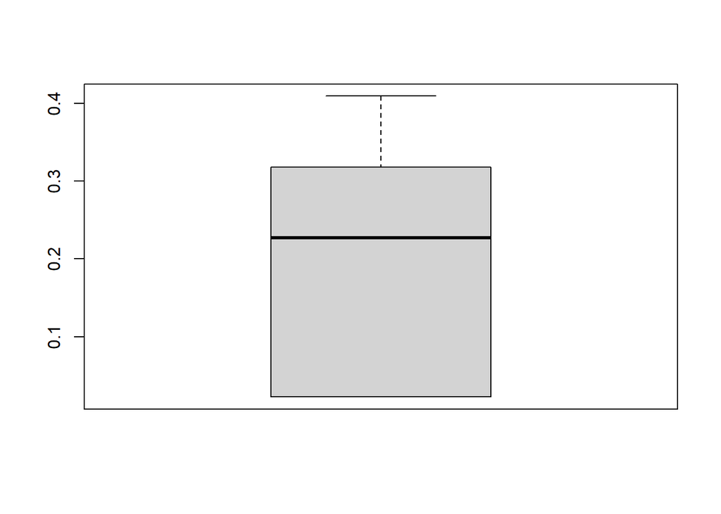

```r
df_perc_empresa_segun_actividad  <- as.data.frame(prop.table(table(survey$empresa_segun_actividad )))
df_perc_empresa_segun_actividad  <- df_perc_empresa_segun_actividad  %>% arrange(-Freq)
boxplot(df_perc_empresa_segun_actividad $Freq)
```

En este boxplot de la distribución de empresas según su actividad, podemos ver los porcentajes de estudiantes según sus preferencia por los rubros de trabajo, aqui se puede observar que la mediana son aquellos estudiantes que prefieren los servicios de proveedores de mantenimiento con el 22%, en el cuarto cuartil se ubican el 40% de los estudiantes que están interesados en el área Bancaria, con esta representacion podemos observar claramente como el área de bancos es una área de alto interés en los estudiantes.

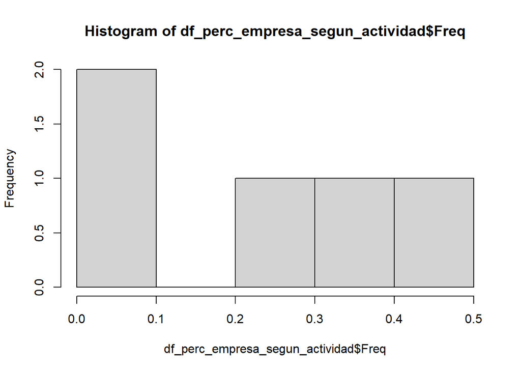

```r
hist(df_perc_empresa_segun_actividad $Freq)
```

Aqui podemos ver el Histograma donde la superficie de cada barra es proporcional a la frecuencia de los valores representados en la variable “empresa_segun_actividad”. Podemos observar la distribución de los datos, permitiendos ver la preferencia, o tendencia, por parte de los estudiantes, que se ubican en cada determinada región.

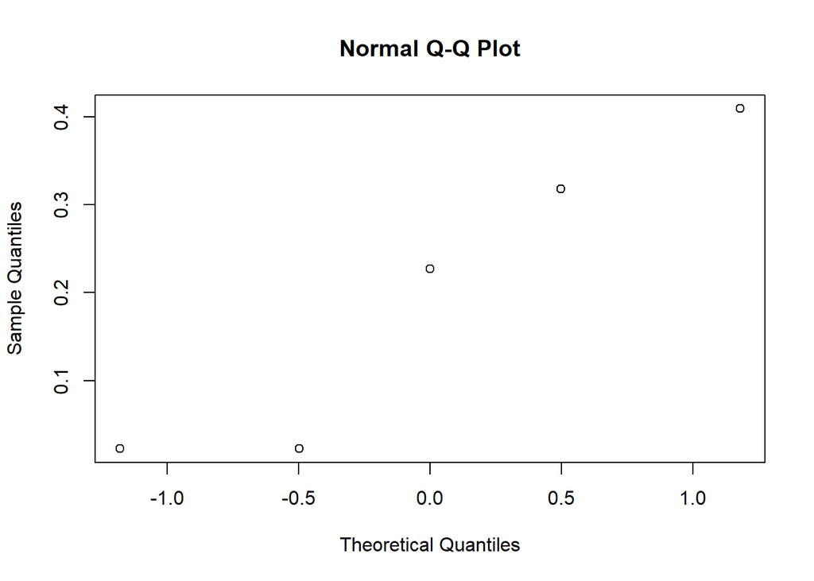

```r
qqnorm(df_perc_empresa_segun_actividad $Freq)
```

En la grafica de quantiles podemos observar como la distribucion de los datos para la variable “empresa_segun_actividad” es normal con una pequeña variacion de la distribucion de la poblacion al inicio.

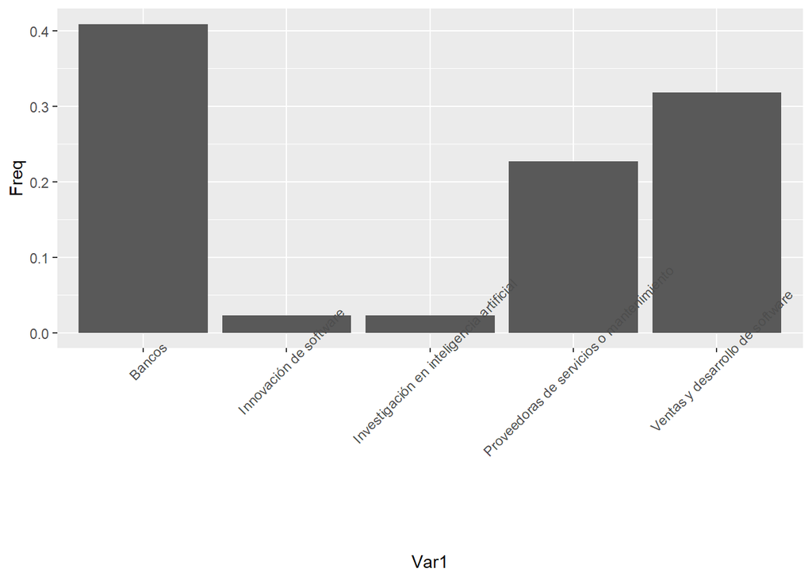

```r
plot2 <- ggplot(df_perc_empresa_segun_actividad, aes(x=Var1, y=Freq)) + geom_bar(stat = "identity")+  theme(axis.text.x = element_text(angle = 45))
print(plot2)
```

Podemos ver en esta representación gráfica un resumen de todo lo antes mencionado y observar mas claramente cómo se distribuyó los porcentajes de estudiantes según como eligieron el área de trabajo dependiendo la actividad que la empresa realiza, se puede ver claramente como las áreas más deseadas o que despiertan mayor interes por los estudiantes para trabajar, serían los bancos y las empresas dedicadas al desarrollo de software.

#### **area_preferida**

en esta variable se puede observar las ramas de interés de los estudiantes de la carrera de ingeniería en sistemas UNAH, aqui analizamos donde los estudiantes de ingenieria en sistemas se sienten mas comodos, o la rama de la carrera que mas llama la atención de los mismos. Se consideran las principales ramas de estudio de la facultad de ingenieria en sistemas UNAH, ya que existen otras ramas de estudio para esta profesion.

```r
survey$area_preferida  <- as.factor(survey$area_preferida )
dq<-as.data.frame(floor(prop.table(table(survey$area_preferida ))*100)) %>% arrange(-Freq)
colnames(dq)<-c("área de interés de la carrera ","Porcentaje % de estudiantes")
dq
```

```
##   área de interés de la carrera  Porcentaje % de estudiantes
## 1         Desarrollo de software                          36
## 2                 Bases de datos                          27
## 3          Seguridad informatica                          20
## 4                Infraestructura                          11
## 5                             BI                           2
## 6                  Investigación                           2
```

La tabla anterior muestra el porcentaje de alumnos ubicados o dividios en cada una de las ramas según el interés de los estudiantes encuestados que es una población de 44 estudiantes, estos datos han sido procesados en la herramienta RStudio utilizando el lenguaje R.

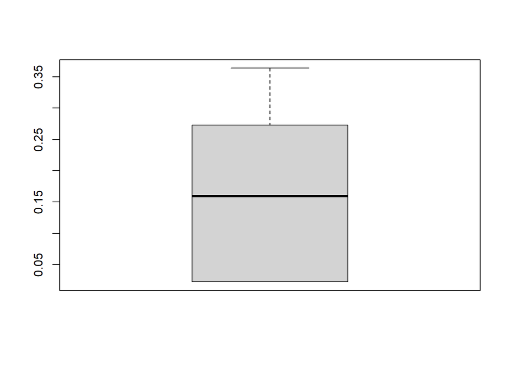

```r
df_perc_area_preferida  <- as.data.frame(prop.table(table(survey$area_preferida )))
df_perc_area_preferida  <- df_perc_area_preferida  %>% arrange(-Freq)
boxplot(df_perc_area_preferida $Freq)
```

En este boxplot podemos ver los porcentajes de estudiantes según sus preferencia en las distintas areas de la carrear de ing en sistesmas,se puede observar que la mediana son el 15% de estudiantes, que el minimo es el 2.27%, en el tercer cuartil se ubican el 27% de los estudiantes que son losinteresados en el área de bases de datos, y como maximo tenemos a el 36% de los estudiantes, que por la tabla anterior podemos ver que son los interesados en el area de desarrollo de software, con esta representacion podemos observar claramente como el área de desarrollo de software es una área que despierta mucho interes en los estudiantes encuestados.

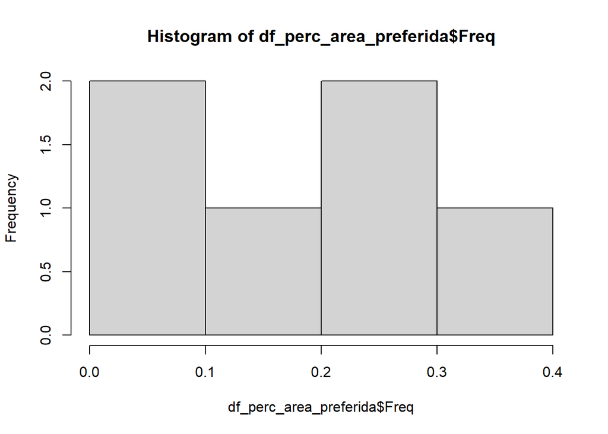

```r
hist(df_perc_area_preferida $Freq)
```

Aqui vemos el Histograma donde la superficie de cada barra es proporcional a la frecuencia de los valores representados en la variable “area_preferida”. Podemos observar la distribución claramente, permitiendos ver la preferencia, o tendencia, por parte de los estudiantes y como se van ubicando en cada determinada región.

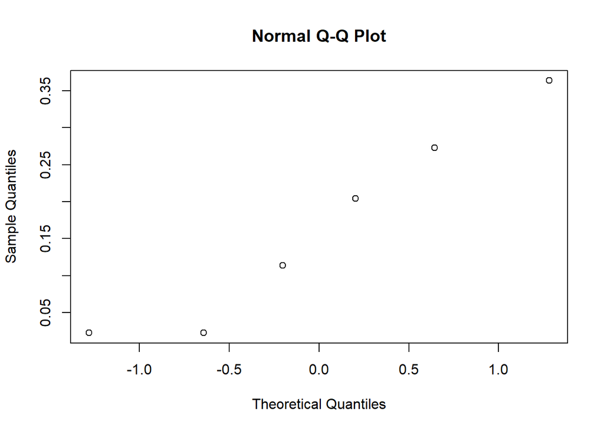

```r
qqnorm(df_perc_area_preferida $Freq)
```

En la grafica de quantiles podemos observar como la distribucion de los datos para la variable “area_preferida” es normal con una pequeña variacion de la distribucion de la poblacion al inicio.

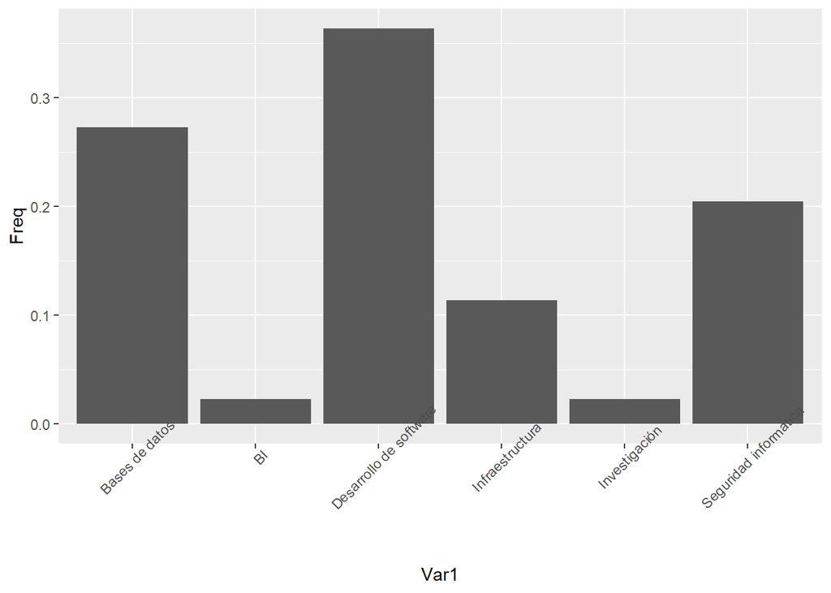

```r
plot2 <- ggplot(df_perc_area_preferida, aes(x=Var1, y=Freq)) + geom_bar(stat = "identity")+  theme(axis.text.x = element_text(angle = 45))
print(plot2)
```

Podemos ver en esta representación gráfica un resumen de todo lo antes mencionado y observar mas claramente cómo se distribuyó los porcentajes de estudiantes por sus intereses o su inclinacion hacialas distintas areas de la carrear, se puede ver claramente como las áreas por la que mas se inclinan o mas despierta intereses en los estudiantes, es desarrollo de software, estando cerca tambien bases de datos y seguridad informatica.

## Correalaciones

##### *Para las correlaciones existen 3 tipos, categorica-categorica, categorica-numerica, numerica-numerica, en el caso puntual de nuestra investigacion no se cuenta con variables numericas por lo que nos centraremos unicamente en correlaciones del tipo categorica-categorica.*

- **Correlacionamos las variables “area_preferida” y “empresa_segun_actividad”**

```
##
##                              Bancos Innovación de software
##   Bases de datos         0.66666667             0.00000000
##   BI                     1.00000000             0.00000000
##   Desarrollo de software 0.31250000             0.00000000
##   Infraestructura        0.20000000             0.00000000
##   Investigación          0.00000000             1.00000000
##   Seguridad informatica  0.33333333             0.00000000
##
##                          Investigación en inteligencia artificial
##   Bases de datos                                       0.00000000
##   BI                                                   0.00000000
##   Desarrollo de software                               0.00000000
##   Infraestructura                                      0.00000000
##   Investigación                                        0.00000000
##   Seguridad informatica                                0.11111111
##
##                          Proveedoras de servicios o mantenimiento
##   Bases de datos                                       0.25000000
##   BI                                                   0.00000000
##   Desarrollo de software                               0.00000000
##   Infraestructura                                      0.60000000
##   Investigación                                        0.00000000
##   Seguridad informatica                                0.44444444
##
##                          Ventas y desarrollo de software
##   Bases de datos                              0.08333333
##   BI                                          0.00000000
##   Desarrollo de software                      0.68750000
##   Infraestructura                             0.20000000
##   Investigación                               0.00000000
##   Seguridad informatica                       0.11111111
```

La primera correlacion que hacemos, es ver si estan relacionadas las areas de interes de trabajo de los estudiantes, con su rama de interes dentro de la carreara de ingenieria en sistemas.

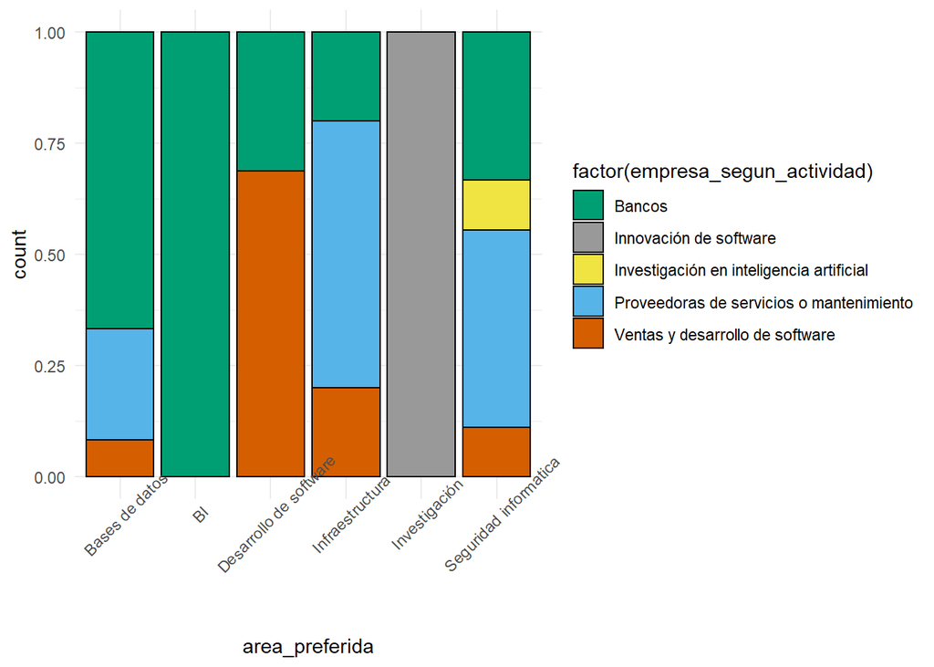

```
##
##  Pearson's Chi-squared test
##
## data:  table(survey$area_preferida, survey$empresa_segun_actividad)
## X-squared = 71.173, df = 20, p-value = 1.171e-07
```

- **H_0 (Hipótesis nula):** Las categorias de area_preferida y empresa_segun_actividad son independientes.
- **H_A (Hipótesis alternativa):** Las categorias son dependientes.

En este pequeño analisis mediante el grafico, podemos ver como los datos obtenidos son fiables y hacen sentido teniendo una relacion logica acertada, donde podemos ver claramente que los rubros empresariales de mayor interes para los estudiantes en este caso Bancos y desarrollo de software van acorde a sus intereses personales de acuerdo a las areas de estudio que mayor porcentaje tienen como ser Desarrollo de software, Base de datos y seguridad informatica.

- **Correlacionamos las variables “area_preferida” y “genero”**

```
##
##                           Femenino Masculino
##   Bases de datos         0.2500000 0.7500000
##   BI                     0.0000000 1.0000000
##   Desarrollo de software 0.2500000 0.7500000
##   Infraestructura        0.6000000 0.4000000
##   Investigación          0.0000000 1.0000000
##   Seguridad informatica  0.3333333 0.6666667
```

La segunda correlacion que hacemos, es ver si estan relacionadas las rama de estudio o interes dentro de la carreara de ingenieria en sistemas con el genero de los estudiantes.

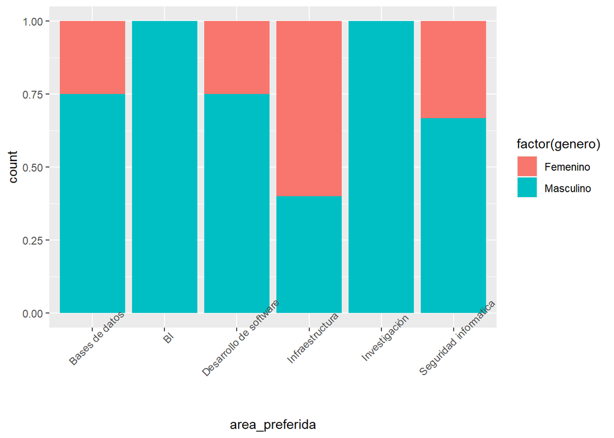

```
##
##  Pearson's Chi-squared test
##
## data:  table(survey$area_preferida, survey$genero)
## X-squared = 3.4065, df = 5, p-value = 0.6376
```

- **H_0 (Hipótesis nula):** Las categorias de area_preferida y genero son independientes.
- **H_A (Hipótesis alternativa):** Las categorias son dependientes.

- **Correlacionamos las variables “empresa_segun_actividad” y “genero”**

```
##
##                                             Femenino Masculino
##   Bancos                                   0.1666667 0.8333333
##   Innovación de software                   0.0000000 1.0000000
##   Investigación en inteligencia artificial 1.0000000 0.0000000
##   Proveedoras de servicios o mantenimiento 0.4000000 0.6000000
##   Ventas y desarrollo de software          0.3571429 0.6428571
```

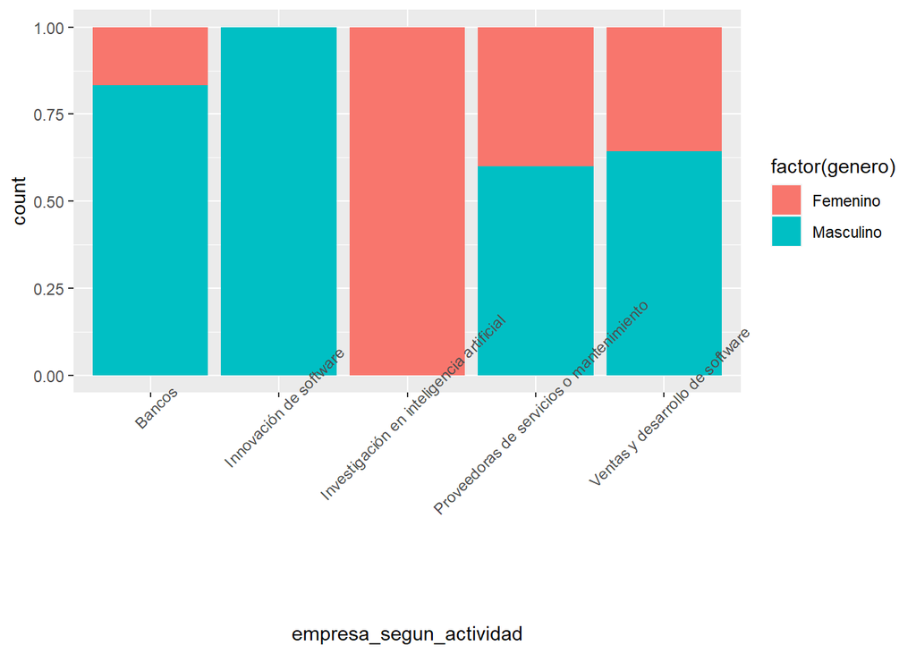

```
##
##  Pearson's Chi-squared test
##
## data:  table(survey$empresa_segun_actividad, survey$genero)
## X-squared = 5.0192, df = 4, p-value = 0.2853
```

- **H_0 (Hipótesis nula):** Las categorias de empresa_segun_actividad y genero son independientes.
- **H_A (Hipótesis alternativa):** Las categorias son dependientes.

## Explicativa

En esta seccion buscamos mostrar las razones o causas que den respuesta a nuestra pregunta de investigacion. y asi tratar de explicar mediante la comprobación de nuestra hipótesis por qué ocurre este fenómeno.

### Regresiones

Recopilamos todas las variables que son importantes para verificar cual es la más influyente con respecto a la de respuesta para ello necesitamos la recopilación a través de RStudio demostrando lo siguiente:

```
##
##        No        Si
## 0.6818182 0.3181818
```

```
##        Overall                            colum
## 1  1.114816969             rango_indice81 o mas
## 2  0.950417029             estudiante_foraneoSi
## 3  0.369336089                rango_indice71-75
## 4  0.315905223                        trabajasi
## 5  0.313615635                rango_indice76-80
## 6  0.109279581                        edad26-30
## 7  0.010771042       rendimiento_academicoMedio
## 8  0.006338524                     edad31 o Mas
## 9  0.004360827 nuevas_habilidades_autodidactaSi
## 10 0.004133348        rendimiento_academicoBajo
```

```
##
## Call:  glm(formula = rechazo_en_entrevista ~ ., family = "binomial",
##     data = set)
##
## Coefficients:
##                      (Intercept)                         edad26-30
##                        -17.25562                           0.08084
##                     edad31 o Mas              estudiante_foraneoSi
##                        -16.94957                          -0.88395
##                        trabajasi                 rango_indice71-75
##                          0.23634                          -0.40349
##                rango_indice76-80              rango_indice81 o mas
##                         -0.32645                          -1.53909
##        rendimiento_academicoBajo        rendimiento_academicoMedio
##                        -16.35227                           0.01220
## nuevas_habilidades_autodidactaSi
##                         17.25222
##
## Degrees of Freedom: 43 Total (i.e. Null);  33 Residual
## Null Deviance:       55.04
## Residual Deviance: 48.4  AIC: 70.4
```

Ya recopilados las variables más influyentes con la regresion aplicada, ordenadas de la más importante a la que menos porcentaje posee, de acuerdo a la variable de respuesta “Rango_indice” es la más influyente teniendo la mayor importancias, para verlo de una manera más clara recopilaremos cada variable con sus respectivos gráficos.

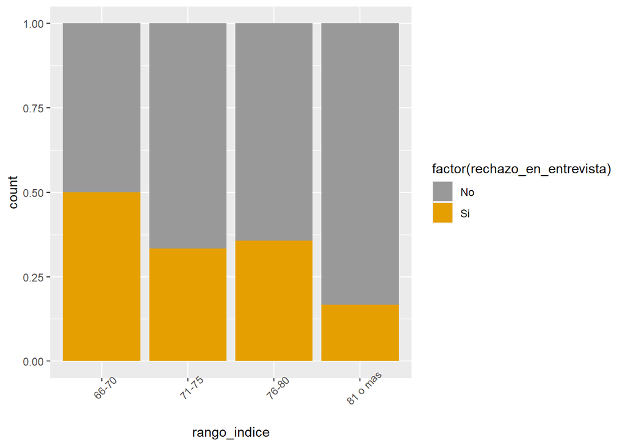

Como se muestra en el grafico anterior el rechazo de las entrevistas se da menos para aquello estudiantes que tienen el índice mayor o igual a 81 los que se encuentran en excelencia académica algo notable se puede ver que las o los estudiantes que tienen mayor rechazo son los que tienen un índice menor a 71. Notamos que la barra del índice 76-80 se nota que hay más rechazo pero no es así, en esa barra la cantidad de personas que tienen ese índice es mayor a la cantidad de personas que están en los índices anteriores, comparando con las barras anteriores notamos que los porcentajes de rechazo son menores.

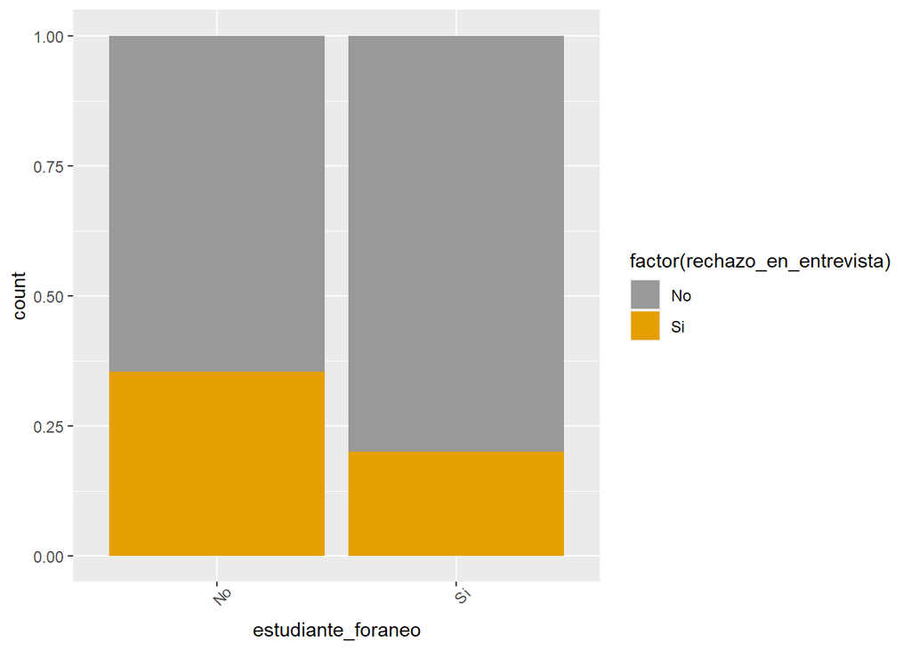

Logramos apreciar en el grafico anterior que los estudiantes que son foráneos tienen mayor aceptación en las entrevistas consiguiendo la aprobación de las empresas para realizar la practica profesional, a comparación a los estudiantes que viven en la capital ellos demuestran que tienden a ser mas rechazados por las empresas, sin embargo, dada la cantidad de estudiantes varia el indice de rechazo y como se muestra la poblacion con mayor numero de consultados son estudiantes de la capital.

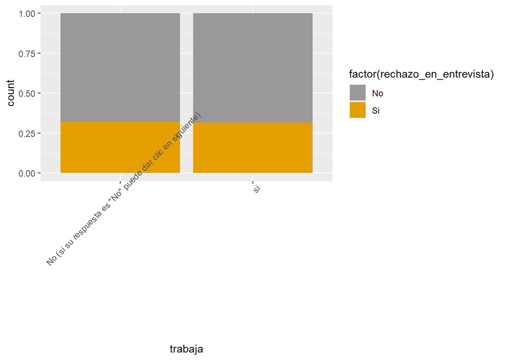

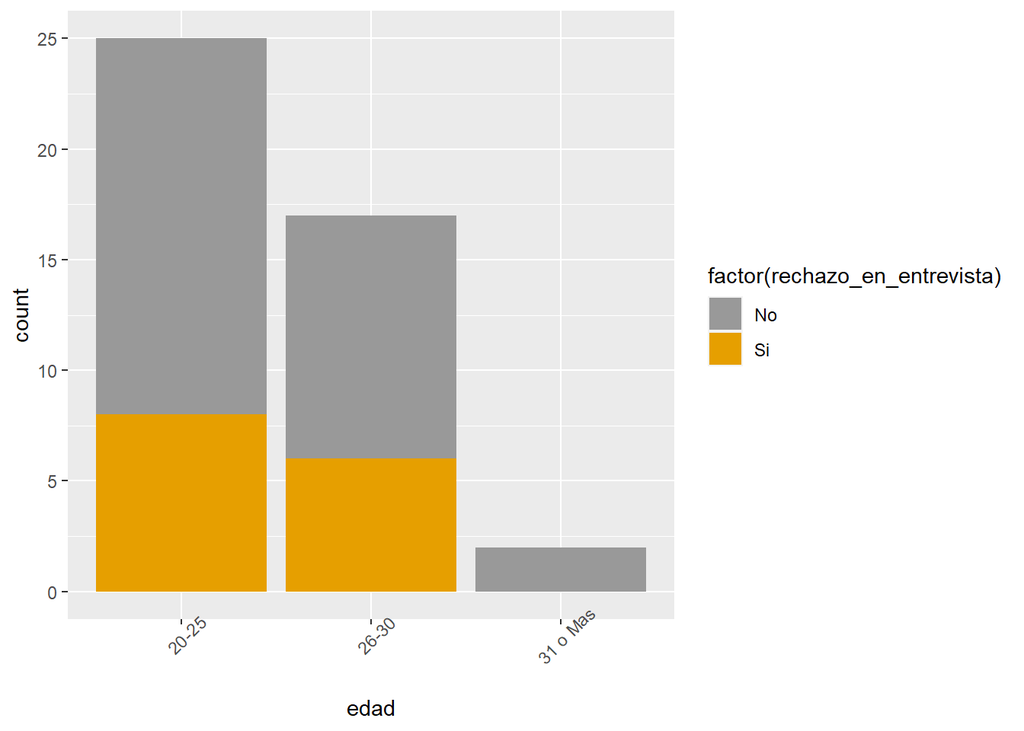

En el grafico anterior vemos que los estudiantes que tienen años de 20-25 tienen menos rechazo en las entrevistas por parte de las empresas, notamos las mismas circunstancias en la barra de las edades de 26-30, podemos decir que las empresas tienen una mayor aceptación a los estudiantes que están a una edad de 20 a 25 años además de que la mayoría de los encuestados son muy jóvenes dándoles más posibilidades de ser aceptados, y a los estúdiates con mayoría de edad tienen aceptación pero no podemos decir que la tiene o no, por la poca cantidad de datos en la ultima proyeccion.

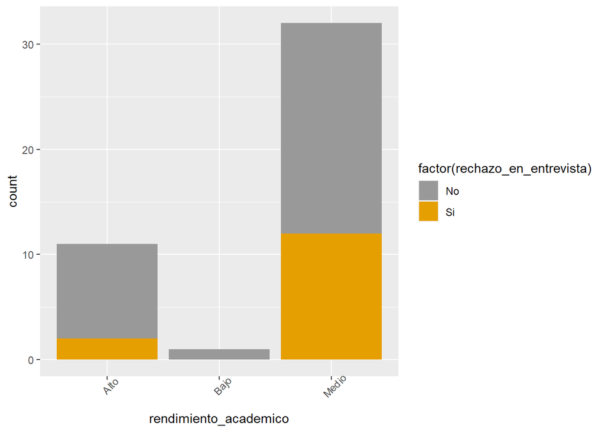

En el grafico anterior vemos con claridad que el estudiantado que tiene alto rendimiento académico obviamente consigue menos rechazo por parte de las empresas, notamos que el rendimiento medio del estudiantado es mas sujeto al a ser rechazado, sin embargo, tambien tienen un gran numero de aceptacion.

### Solucion tecnologica

Con toda la informacion mostrada anteriormente, vemos como el problema de nuestro estudio necesita una solucion, para este caso en particular se propone una solucion basada en tecnologia a continuacion mostramos en que consite nuestra solucion:

[figure not shown]

Ilustración Arquitectura propuesta tecnológica Fuente: (Propia, Fuente Propia, 2020)

Esta solución tecnológica está diseñada y pensada para ser utilizada en diferentes plataformas y dispositivos a través de la web, esto nos da la facilidad y flexibilidad de llegar al mayor número de usuarios, simplificando costos y esfuerzo de desarrollo y así mismo ser un producto multiplataforma y multi sistema operativo, ya que únicamente se necesitara un explorador web y una conexión a internet. Buscamos que nuestro sistema sea de rápida implementación y fácilmente escalable, para un futuro crecimiento exponencial , ya que el área de nuestra investigación es una de las áreas más demandadas en el país el área laboral. Para lograr esta escalabilidad, y obtener una fácil y rápida implementación destacamos el almacenamiento de información en la nube a través de amazon. Utilizando su gama de servicios en la nube de su plataforma online Amazon Web services junto los servicios de Amazon ML (Machine Learning).

#### Comunicación de servicios

[figure not shown]

Servicio Usuario Servidor

En este pequeño diagrama podemos ver como esta estructurado el servicio de acceso del usuario a el sistema, en este punto la interacción que buscamos es que sea de la manera mas sencilla posible para que cualquiera pueda tener acceso y sea de fácil uso, básicamente los requisitos para el usuario es contar con cualquier dispositivo que se conecte a internet y contar con una conexión de datos de internet, con esto logramos ser accesibles desde cualquier plataforma sin importar si es un dispositivo móvil , computadora, o sin importar el sistema operativo del usuario. La funcionalidad de este servicio es básicamente lograr la interacción y recopilación de datos con el usuario, este diagrama en especifico si se presta una atención detallada al diagrama general se puede observar como se divide en 2 servicios, esto es porque un servicio será la interacción con las empresas que proveerán de datos de ofertas laborales al sistema, y el otro es la interacción del usuario que proveerá de datos de su perfil personal y sus preferencias personales al sistema, como se puede ver aunque son servicios que funcionaran por separado tienen la misma lógica aplicada en este diagrama en el cual podemos ver que la funcionalidad principal que buscamos con este servicio es la recolección de datos . Donde el usuario ingresa a la plataforma de Integración Empresarial a través de internet generando con esto una interacción entre el sitio web alojado en servidores web de amazon contra el api del backend también alojada en los servidores de la nube de Amazon, luego posterior mente el api servirá como intermedio entre los datos del usuario y la base de datos ya sea para almacenar la información ingresada por el usuario o para consultarla siendo la función principal del api servir o almacenar mediante la base de datos, información de relevancia para el usuario.

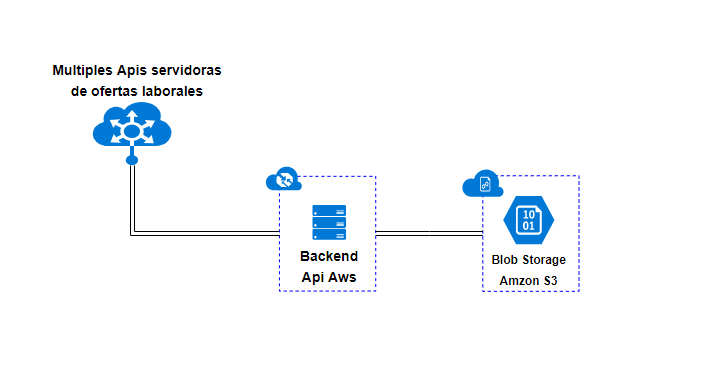

Servicio Recoleccion de ofertas de apis de terceros

En este diagrama queremos mostrar como tendremos un segundo servicio de recolección de datos para el área de ofertas laborales que estarán disponibles en nuestro sitio, como se menciono en la parte anterior existe un acceso para empresas que dotara de información de cv a nuestra base de datos, pero este puede que no sea siempre el caso, y si esto sucede dejaría prácticamente sin funcionalidad nuestra plataforma, para solucionar este problema y dotar de dinamismo nuestro sitio y que no dependa de alguien que alimente de ofertas laborales se implementa el servicio de recolección de data de Apis de terceros, este consistirá en básicamente consultar sitios web que tengan ofertas laborales y obtener estos datos en una comunicación directa entre nuestra api y las Apis de terceros donde nuestra api hará peticiones a las Apis de terceros recolectando así estas ofertas laborales , y buscando estructurar esta información para almacenarla en nuestra base de datos. En caso de que esta información obtenida no sea de forma estructurada ya que puede venir de archivos de texto, pdf, archivos json etc, nuestra api lo que hará con esta información no estructurada será almacenarla tal cual la encontró en el almacenamiento de amazon S3 o blob storage donde esto nos permitirá ser accedida mas adelante para darle un tratamiento especial a estos datos para luego mostrar estos al usuario. El objetivo principal que buscamos con este servicio claramente es la recopilación de la mayor cantidad de ofertas laborales para tener una gran variedad de opciones en nuestra data y que este así disponible para nuestros usuarios.

[figure not shown]

Servicio deAmazon ML (Machine Learning)

la base de nuestro sistema serán las recomendaciones , pero no queremos que sean cualquier tipo de recomendaciones de forma aleatoria, queremos lograr que nuestro sistema tenga un plus, y para esto queremos sacar ventajas del machine learning . Los sistemas de recomendación de contenidos se han hecho muy populares en los últimos años. Entre los ámbitos más extendidos se encuentran las recomendaciones de productos en tiendas online, películas, vídeos, música, libros, productos o recomendaciones de perfiles. Los Sistemas de Recomendación intentan personalizar al máximo lo que ofrecerán a cada usuario. A nivel de nuestra arquitectura se puede observar el servicio de ML (Machine Learning), y atraves de estos servicios que ofrece amazon web services de ML (Machine Learning), queremos llegar a lograr este objetivo, ya que con estas soluciones que nos ofrece esta empresa es mucho más fácil, rápido y menos costoso implementar este tipo de sistemas aprovechando las herramientas de ML (Machine Learning) que amazon pone a nuestro alcance esto se hace posible. Como podemos observar en nuestra arquitectura para llegar a este servicio en especifico hacemos un flujo de recolección de datos previamente para así crear nuestro dataSet que puede ser de datos estructurados (sql) almacenados en la base de datos o datos no estrucurados(pdf,texto,json..etc) que estarian almacenados en el blob storage y asi dotar de la información valiosa y necesaria a nuestro servicio de ML (Machine Learning) para así poder trabajar estos datos. Con todo esto lograríamos exprimir estas ventajas de ML (Machine Learning), y así lograr un sistema de recomendación afinado para nuestro caso de estudio donde gestionaríamos nuestro Collaborative Filtering, pues utiliza la información de «masas» para identificar perfiles similares y aprender de los datos para recomendar productos de manera individual en nuestro caso ofertas laborales personalizadas.

[figure not shown]

Servicio de notificaciones al usaurio

En este pequeño diagrama podemos ver como está estructurado el servicio de notificaciones al usuario, este servicio básicamente, funcionara mediante la comunicación de correo electrónico y esta se lograra gracias a otra de las opciones que nos brinda la plataforma de amazon en la nube que es el Amazon Simple Email Service (ASES). El objetivo general de este servicio es comunicar al usuario de ofertas laborales que pueden ser de su interés , pero este servicio en específico para nuestro sistema lo hemos dividido en dos partes a nivel de funcionalidad. La primera parte es donde buscamos trabajar por el estudiante de la UNAH mucho antes de que el incluso separa que esta herramienta en línea existe, esto lo logramos comunicando nuestra api directamente con la api de la universidad (UNAH) donde de ellos obtendremos únicamente el correo institucional, siendo esta una información que la unah provee de forma publica a los maestros todos los periodos, nosotros la solicitaremos a través de nuestra api únicamente de los estudiantes que tengan la característica o que estén catalogados por la UNAH como estudiantes por egresar , enviando así ofertas laborales almacenadas en nuestro sistema como mostramos en los diagramas previos, y que sean del interés del estudiante acorde a su área de estudio directamente a su correo electrónico. La segunda parte de esta es que si un estudiante le parece interesante la información que está recibiendo a través de su correo electrónico mediante nuestra plataforma, puede acceder a este y registrarse como un usuario, llenar su perfil, detallando sus intereses personales y laborales, luego nuestro sistema analizaría sus datos y mediante ML (Machine Learning), buscaríamos para este la oferta laborales que mas se ajusten a su perfil mediante el sistemas de recomendación de perfiles laborales, siendo este estudiante nuevamente notificado mediante correo electrónico y mostrándole asi que se encontró una coincidencia para su perfil.